# Администрирование локальных сетей

Лабораторная работа №9. Использование протокола STP. Агрегирование каналов

Илья Колонтырский

Российский университет дружбы народов, Москва, Россия

07.04.2026

# Цели и задачи работы

## Цель лабораторной работы

Изучить возможности протокола **STP** и его модификации **Rapid PVST+** по обеспечению отказоустойчивости сети, а также освоить агрегирование каналов между коммутаторами.

## Задачи

- сформировать резервное соединение между коммутаторами;
- исследовать прохождение трафика ICMP при работе STP;
- определить корневой коммутатор для **VLAN 3**;
- переназначить root bridge;
- включить режим **PortFast** на серверных портах;
- сравнить отказоустойчивость **STP** и **Rapid PVST+**;
- настроить агрегированный канал **EtherChannel**.

# Исходная топология и резервное соединение

## Топология после формирования резервного канала

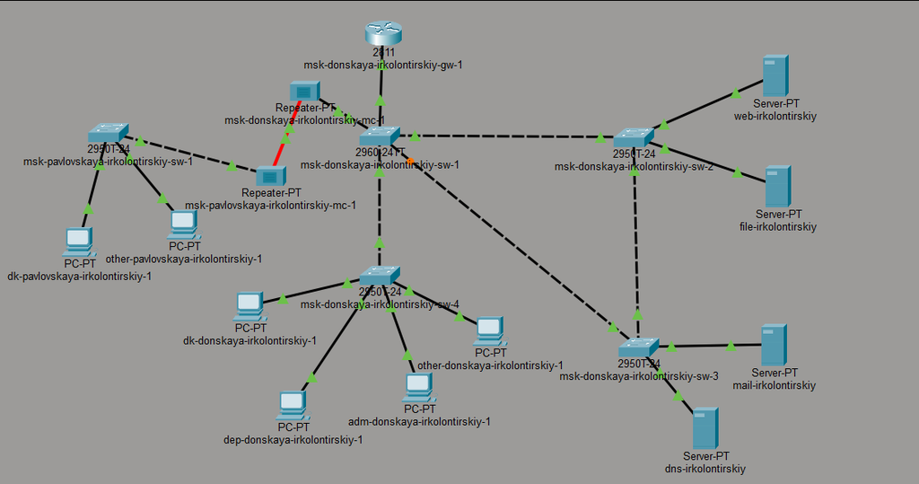

Изменённая физическая топология сети с резервным соединением между коммутаторами

# Проверка прохождения трафика

## Проверка ICMP-трафика до смены root bridge

С узла **dk-donskaya-irkolontirskiy-1** выполнена проверка доступности серверов **mail** и **web**.

Наблюдения:

- трафик проходил через коммутатор **msk-donskaya-irkolontirskiy-sw-2**;
- один из избыточных каналов был заблокирован STP;
- при перестроении дерева наблюдались единичные потери пакетов.

## Симуляция прохождения ICMP-пакетов

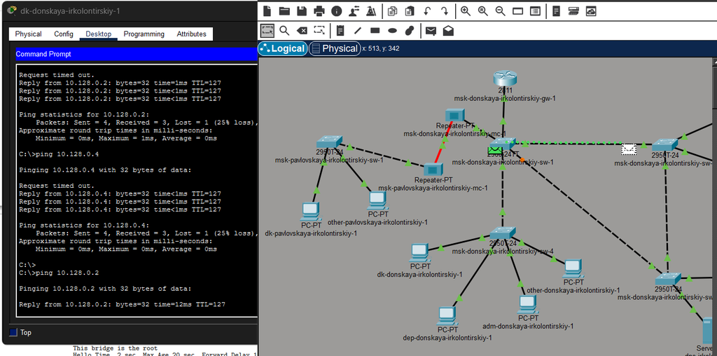

Проверка ICMP-трафика в режиме симуляции до переназначения корневого коммутатора

## Дополнительная проверка активного маршрута

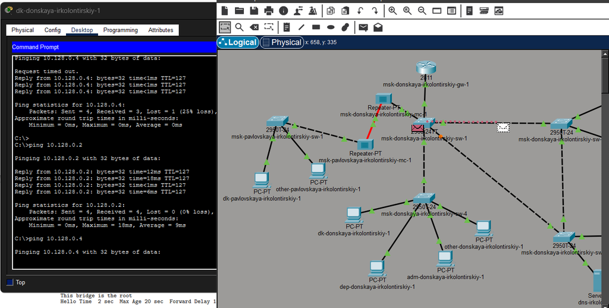

Дополнительная проверка прохождения ICMP-пакетов через активный путь сети

# Анализ STP

## Вывод состояния STP на sw-2

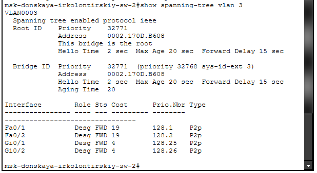

Состояние протокола STP для VLAN 3 на коммутаторе msk-donskaya-sw-2

## Состояние STP для VLAN 3

По результатам видно, что:

- устройство являлось **корневым мостом**;
- в выводе присутствует строка **This bridge is the root**;
- активные интерфейсы находились в состоянии **Designated Forwarding**.

## Подтверждение смены root bridge

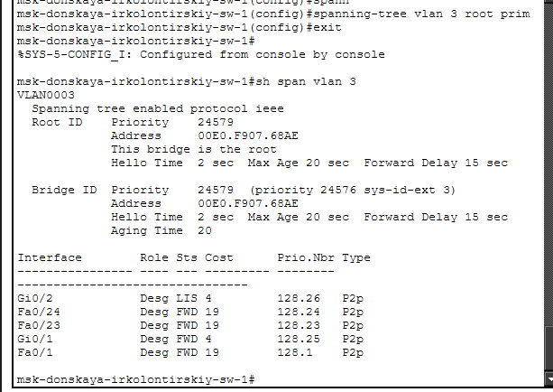

Настройка коммутатора msk-donskaya-sw-1 в качестве корневого моста VLAN 3

## Назначение нового root bridge

После изменения:

- **sw-1** стал корневым мостом;
- дерево STP было пересчитано;
- один из резервных интерфейсов перешёл в блокирующее состояние.

# Новый маршрут прохождения трафика

## Проверка маршрутов после смены root bridge

После перерасчёта STP трафик стал проходить следующим образом:

- до сервера **mail**: **dk-donskaya-1 → sw-1 → sw-3 → mail**
- до сервера **web**: **dk-donskaya-1 → sw-1 → sw-2 → web**

Это подтвердило корректное изменение логического дерева STP.

## Проверка прохождения трафика

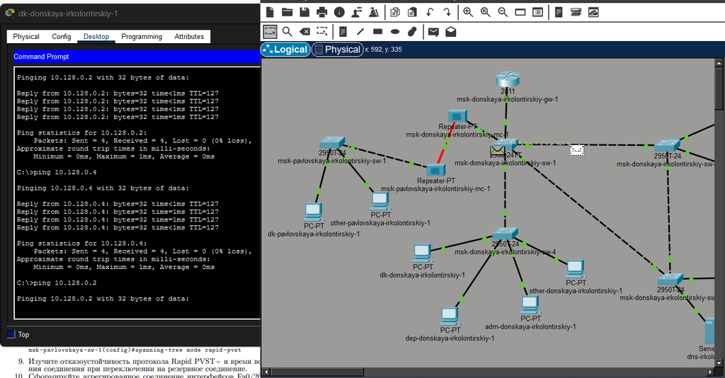

Проверка прохождения ICMP-трафика после смены корневого коммутатора

## Маршрут до сервера mail

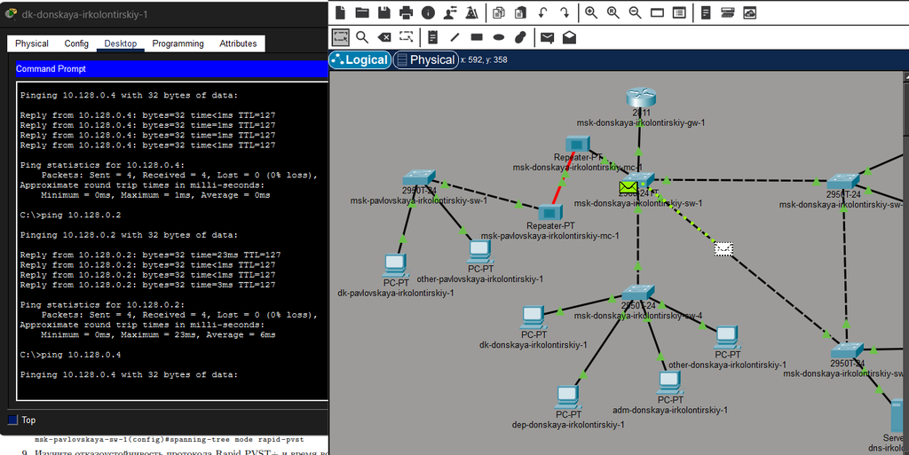

Маршрут трафика до сервера mail через msk-donskaya-sw-3

# Настройка PortFast

## Включение PortFast на серверных портах

Назначение PortFast:

- ускоренный переход access-порта в состояние **Forwarding**;
- сокращение времени ожидания при подключении серверов;
- применение только на портах, ведущих к конечным устройствам.

## Настройка PortFast на sw-2

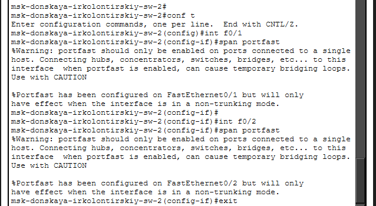

Настройка режима PortFast на серверных портах коммутатора msk-donskaya-sw-2

## Настройка PortFast на sw-3

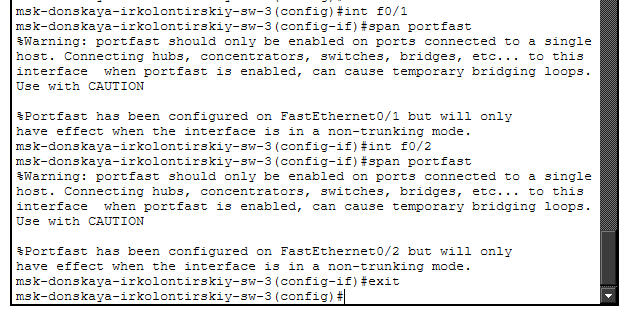

Настройка режима PortFast на серверных портах коммутатора msk-donskaya-sw-3

# Отказоустойчивость STP

## Проверка восстановления связи при отказе

Результат:

- во время перерасчёта дерева наблюдались **Request timed out**;
- после сходимости STP передача пакетов восстанавливалась;
- восстановление связи занимало заметное время.

## Отказоустойчивость классического STP

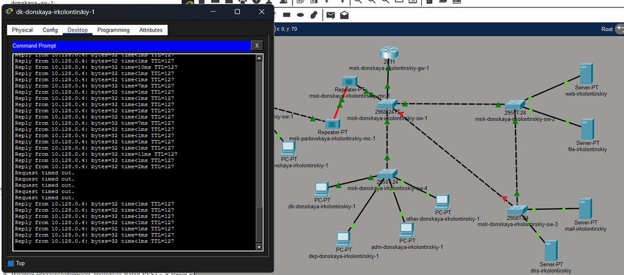

Проверка отказоустойчивости STP при разрыве активного соединения

# Переход на Rapid PVST+

## Перевод коммутаторов в режим Rapid PVST+

Ожидаемый эффект:

- более быстрая сходимость;
- ускоренное включение резервного маршрута;
- уменьшение времени простоя сети при отказе линка.

## Подтверждение перехода на Rapid PVST+

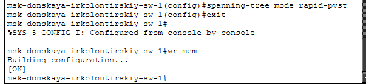

Перевод коммутаторов в режим Rapid PVST+

## Проверка отказоустойчивости Rapid PVST+

Результаты:

- резервный путь активировался быстрее;
- количество потерянных ICMP-пакетов уменьшилось;
- сеть восстанавливалась заметно быстрее, чем при классическом STP.

## Отказоустойчивость после перехода на Rapid PVST+

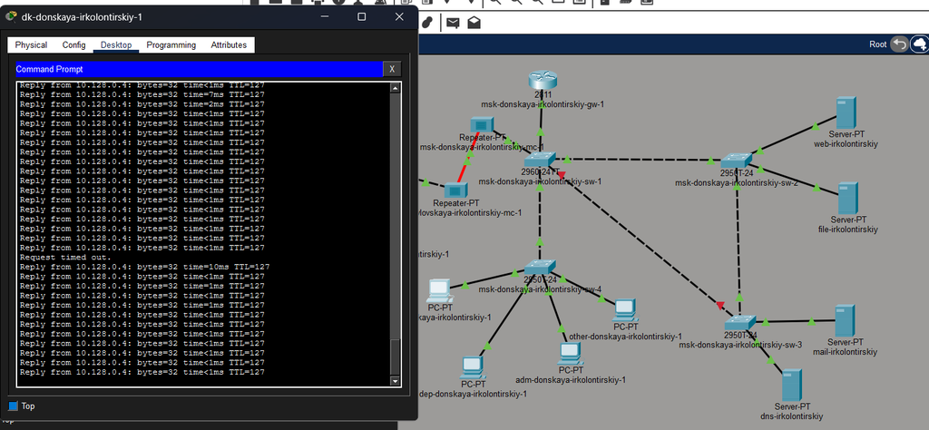

Проверка отказоустойчивости сети после перехода на Rapid PVST+

# EtherChannel

## Формирование агрегированного канала

Преимущества агрегирования:

- увеличение пропускной способности;
- логическое объединение нескольких физических каналов;
- повышение отказоустойчивости.

## Схема агрегированного соединения

[figure not shown]

Агрегированное соединение между коммутаторами msk-donskaya-sw-1 и msk-donskaya-sw-4

## Настройка EtherChannel

Использованные сущности Cisco:

- **EtherChannel** — технология агрегирования;
- **port-channel** — логический интерфейс;
- **channel-group** — привязка физических портов к логическому каналу.

## Настройка EtherChannel на sw-4

[figure not shown]

Настройка EtherChannel на коммутаторе msk-donskaya-sw-4

## Проверка доступности серверов после EtherChannel

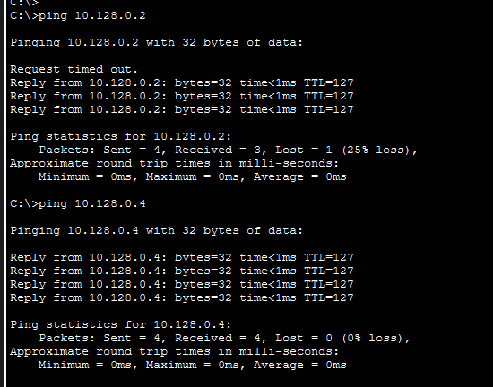

Проверка доступности серверов после настройки EtherChannel

# Итоги работы

## Вывод

Полученные результаты:

- сформировано резервное соединение между коммутаторами;
- исследовано поведение STP при наличии избыточных каналов;
- выполнено переназначение корневого коммутатора для **VLAN 3**;
- включён режим **PortFast** на серверных интерфейсах;
- подтверждено, что **Rapid PVST+** обеспечивает более быструю сходимость;
- реализован **EtherChannel** между **sw-1** и **sw-4**;
- подтверждена работоспособность сети после агрегирования каналов.